# How disrupted spatial fluxes reshape food web structure along the river–sea continuum

A preliminary case study on the effect of primary productivity along the estuary-sea continuum

Ismaël Lajaaiti, Alain Danet, Anik Brind’Amour, Eric Edeline

May 26, 2026

# Introduction

## The river-estuary-sea continuum

[figure not shown]

Garonne estuary – © CNES 2020

- From satellite view, rivers, estuary and sea are obviously connected in space
  - By flux of nutrients, organic matter
  - By migratory species (salmon, etc.)
- Yet rivers, estuaries and seas are often studied separately
  - Different fields: freshwater vs estuary vs marine ecology
  - Different surveys, data set, concepts that prevent connexions to be made
- Need to account for the river-sea continuum as disturbances propagate in space
  - Algae bloom, dams and migratory species, etc.

## The River Continuum Concept

- Species turnover $\rightarrow$ function replacement $\rightarrow$ efficient use of energy input
- Focus on the main stream, ignore the dendritic river network
  - Food Pulse and River Wave concepts (Junk et al. 1989; Humphries et al. 2014)
- Ignore disturbance impacts (dams, nutrients overloads)
  - Serial Discontinuity Concept (Ward and Stanford 1983)
  - Meta-ecosystem theory (Gounand et al. 2018)
- Stops at the estuary
- **Pattern of food web structure is largely unknown**

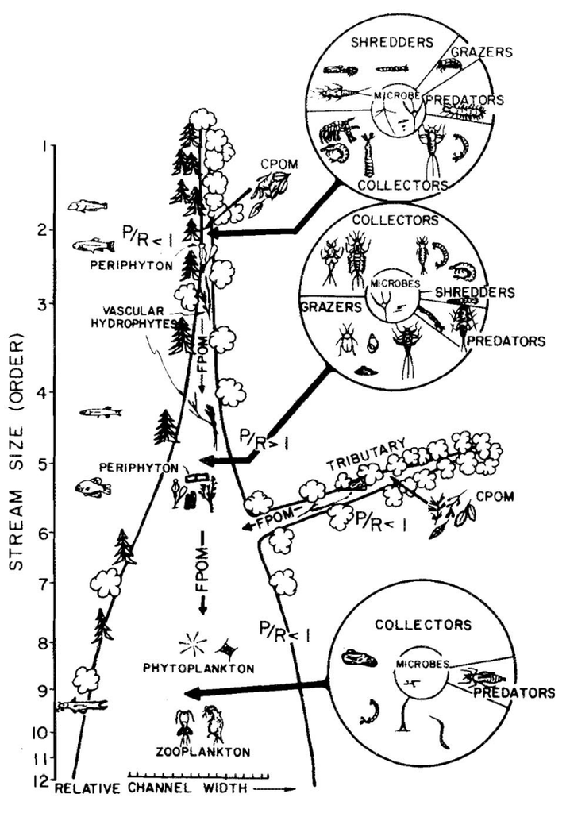

Vannote et al. (1980)

# How disrupted spatial fluxes reshape food web structure along the river–sea continuum

# Case study: How primary productivity shape food web structure along the estuary-sea continuum

## Expectation regarding food web structure responses

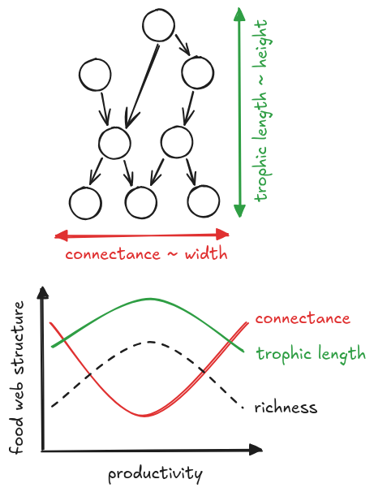

*Expected trends of food web structure with productivity*

- Two main *dimensions* of food webs
- Widely used metrics in the literature
- Expectation of their response to environment and stressors
  - Unimodal relationship between trophic length and primary productivity
  - ~ reversed relationship for connectance
- We can already identify species richness as a mediator variable

## Standing questions and statistical challenges

### How to …

- … efficiently model such a large dataset
  - R-INLA sounds promising
- … handle temporal autocorrelation
  - Autoregressif process (AR1)
- … handle spatial autocorrelation
  - BYM – random effect where neighbours share information via adjacency graph
- … integrate survey data with different protocoles
  - Include in the model as a categorical variable
  - Can it be disentangled from the environment?

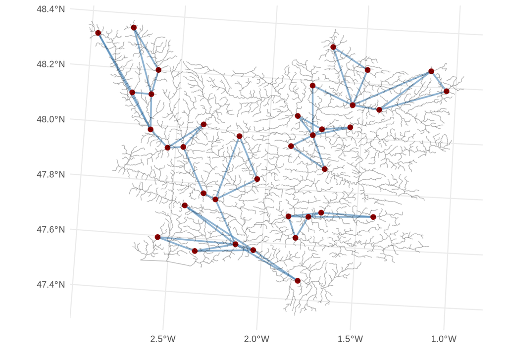

*Example of autocorrelation graph in La Vilaine Nodes are connected respective to **hydrographic** distances*

# Methods

## Where we start from

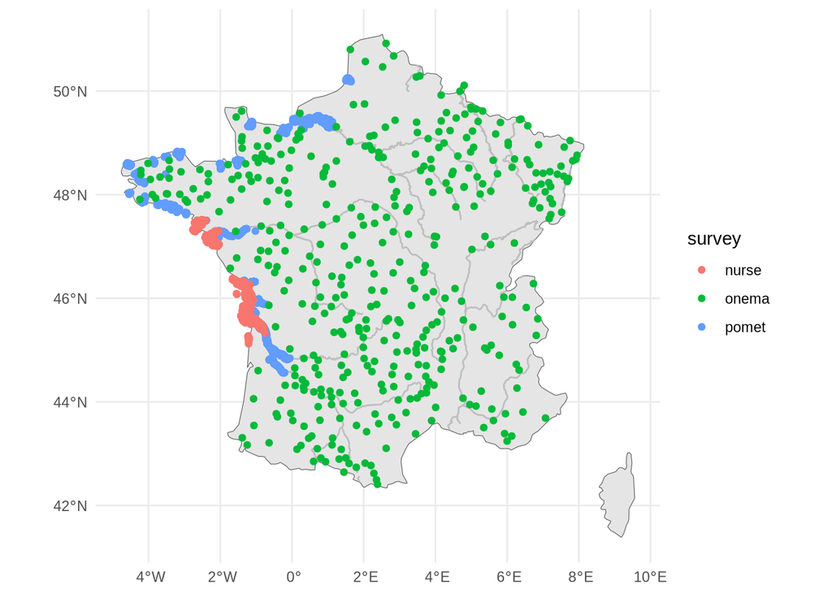

*Map of the sampling points (fishing operation) for the coastal, estuarine and riverine data.*

- *River survey – Onema*
  - Excluded for the case study
  - Previously processed by Alain Danet
- **Estuary and coast surveys – Pomet & Nurse**
  - Current focus
- Long time series, e.g. Nurse survey started in 1980
  - Not continuous, there are some gaps
  - Different protocoles: electrofishing vs trawling
- Species abundances and individual fish size

## From this we reconstruct food web

- Metaweb approach inspired by (Bonnaffé et al. 2021)
- Extract fish diet with `rfishbase`
- Diet changes with ontogeny
  - Distinguish between juveniles and adults
  - Not only species composition but also size distribution affect food web structure
- Piscivorous interaction infered with predation window
  - Big fish eat little fish
  - 3-45% body size window
- From the metaweb, we we infer local food web by subsampling

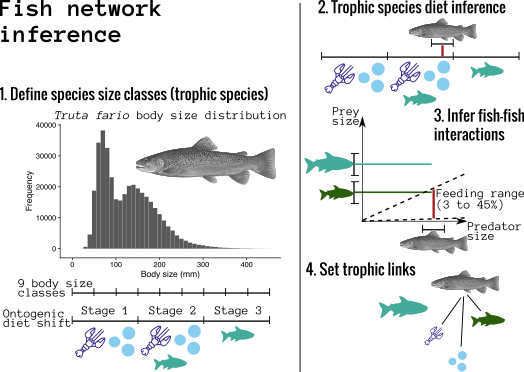

*Sketch of the steps to build the metaweb*

## Environmental variables and our first model

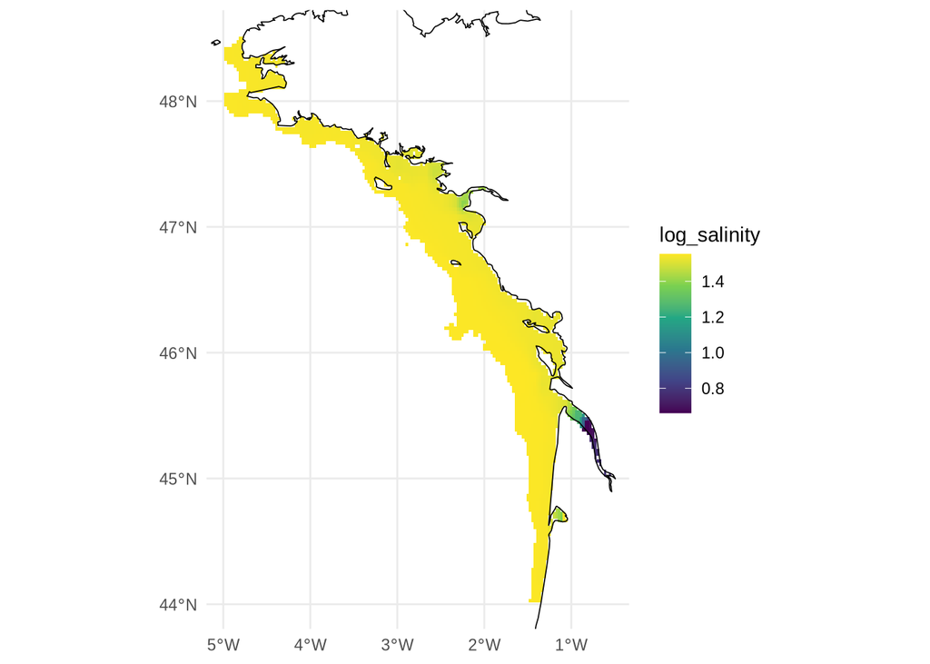

*Salinity levels in 2023*

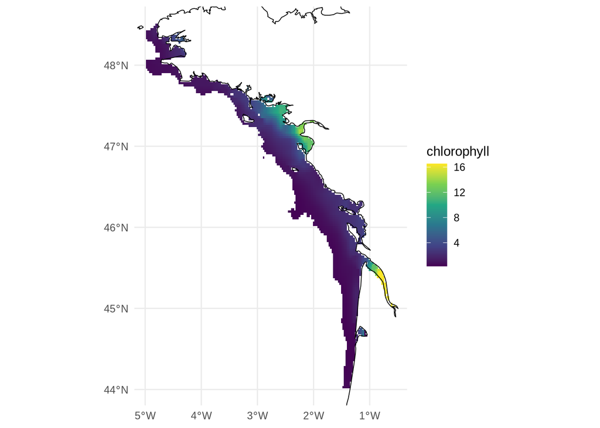

*Chlorophyll levels in 2023*

**Linear Model**
$$\text{structure} \sim \text{salinity} + \text{chlorophyll} +
\text{salinity} \times \text{chlorophyll} + \text{year}_i + \text{zone}_i$$

# Results

## How salinity and productivity shape food web structure

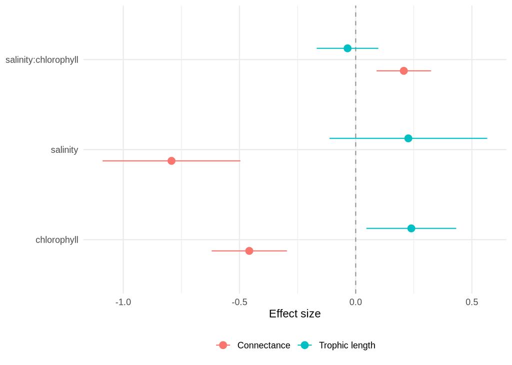

- According to expectations
  - Negative effect of productivity on connectance
  - Opposite trends for trophic length
- Negative effect of salinity on connectance
  - Coastal communities richer than estuary ones
- Is the effect driven by richness only? Diet, fish size.
- How to quantify indirect pathways? SEM (appendix), joint models.
- How to assess model validity regarding spatiotemporal autocorrelations?

# Thank you! Questions?

# Appendix

## Decomposing environmental effects with a SEM

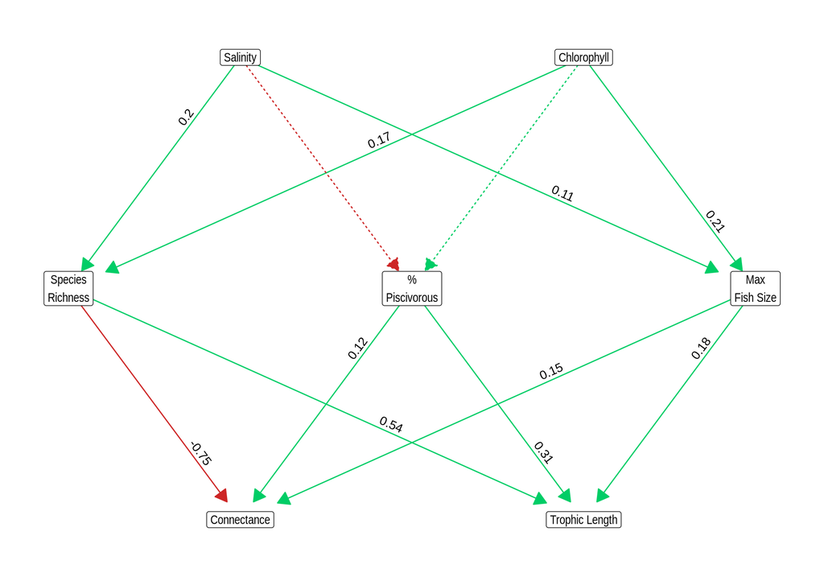

## Stressors and how they interact

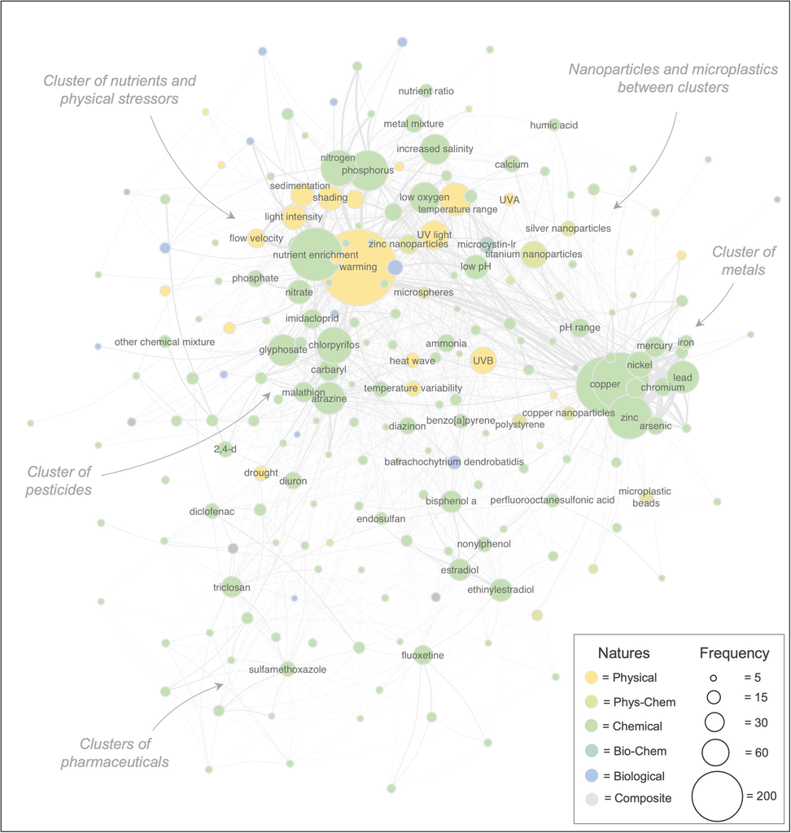

Orr et al. (2024)

- We focus on stressors that impact connexion between ecosystems
  - Dams, nutrient overloads
  - A local effect that can ripple throughout the continuum
- And stressors that can interact with those
  - Temperature $\times$ nutrients
  - Expected in theory to be antagonistic (Binzer et al. 2012)
  - But not supported by empirical data (Bonnaffé et al. 2024)

## References

Binzer, Amrei, Christian Guill, Ulrich Brose, and Björn C. Rall. 2012. “The Dynamics of Food Chains Under Climate Change and Nutrient Enrichment.” *Philosophical Transactions of the Royal Society B: Biological Sciences* 367 (1605): 2935–44. https://doi.org/10.1098/rstb.2012.0230.

Bonnaffé, Willem, Alain Danet, Camille Leclerc, Victor Frossard, Eric Edeline, and Arnaud Sentis. 2024. “The Interaction Between Warming and Enrichment Accelerates Food-Web Simplification in Freshwater Systems.” *Ecology Letters* 27 (8): e14480. https://doi.org/10.1111/ele.14480.

Bonnaffé, Willem, Alain Danet, Stéphane Legendre, and Eric Edeline. 2021. “Comparison of Size-Structured and Species-Level Trophic Networks Reveals Antagonistic Effects of Temperature on Vertical Trophic Diversity at the Population and Species Level.” *Oikos* 130 (8): 1297–309. https://doi.org/10.1111/oik.08173.

Gounand, Isabelle, Eric Harvey, Chelsea J. Little, and Florian Altermatt. 2018. “Meta-Ecosystems 2.0: Rooting the Theory into the Field.” *Trends in Ecology & Evolution* 33 (1): 36–46. https://doi.org/10.1016/j.tree.2017.10.006.

Humphries, Paul, Hubert Keckeis, and Brian Finlayson. 2014. “The River Wave Concept: Integrating River Ecosystem Models.” *BioScience* 64 (10): 870–82. https://doi.org/10.1093/biosci/biu130.

Junk, W. J., Peter Bayley, and Richard Sparks. 1989. “The Flood Pulse Concept in River-Floodplain Systems.” *Canadian Special Publication of Fisheries and Aquatic Sciences* 106 (September): 110–27.

Orr, James A., Samuel J. Macaulay, Adriana Mordente, et al. 2024. “Studying Interactions Among Anthropogenic Stressors in Freshwater Ecosystems: A Systematic Review of 2396 Multiple-Stressor Experiments.” *Ecology Letters* 27 (6): e14463. https://doi.org/10.1111/ele.14463.

Vannote, Robin L., G. Wayne Minshall, Kenneth W. Cummins, James R. Sedell, and Colbert E. Cushing. 1980. “The River Continuum Concept.” *Canadian Journal of Fisheries and Aquatic Sciences* 37 (1): 130–37. https://doi.org/10.1139/f80-017.

Ward, J., and Jack Stanford. 1983. “The Serial Discontinuity Concept of Lotic Ecosystems.” *Dynamics of Lotic Ecosystems* 10 (January).